# Classifying Red Wine vs. White Wine

# Aim

The Aim of this document is to build a model to classify red and white wine by using a a dataset which was merged out of two separate ones. This is for my own learning purpose and to recap learned methods.

The success will be measured with the accuracy in correctly classifying types of wine in an unseen test dataset.

We will try to achiev this goal by trying differnet types of models and methods for variable selection.

# Load packages and data

At first we need to load the required packages…

```r
require(tidyverse, quietly = T) # for data manipulating and visualisation
require(GGally, quietly = T)# for ggpairs plot
require(caret, quietly = T) # for doing k-fold cross validation model training
require(bestglm) # for best subset selection
require(rpart) # for decision tree
require(randomForest) # for random forest
```

After that we will load the dataset into our workspace:

```r
wines0 <- readRDS("./data/wineQualityCombined.RDS")
```

The original dataset has a `quality` variable which can be used for training purpose on regression problems. Since we only want to start with classifying red- vs. white wine, we will remove this variable from the data.

```r
wines <- wines0 %>%
  select(-quality)
```

# Data overview

At first we will use `ggpairs`to compare the variables in the dataset

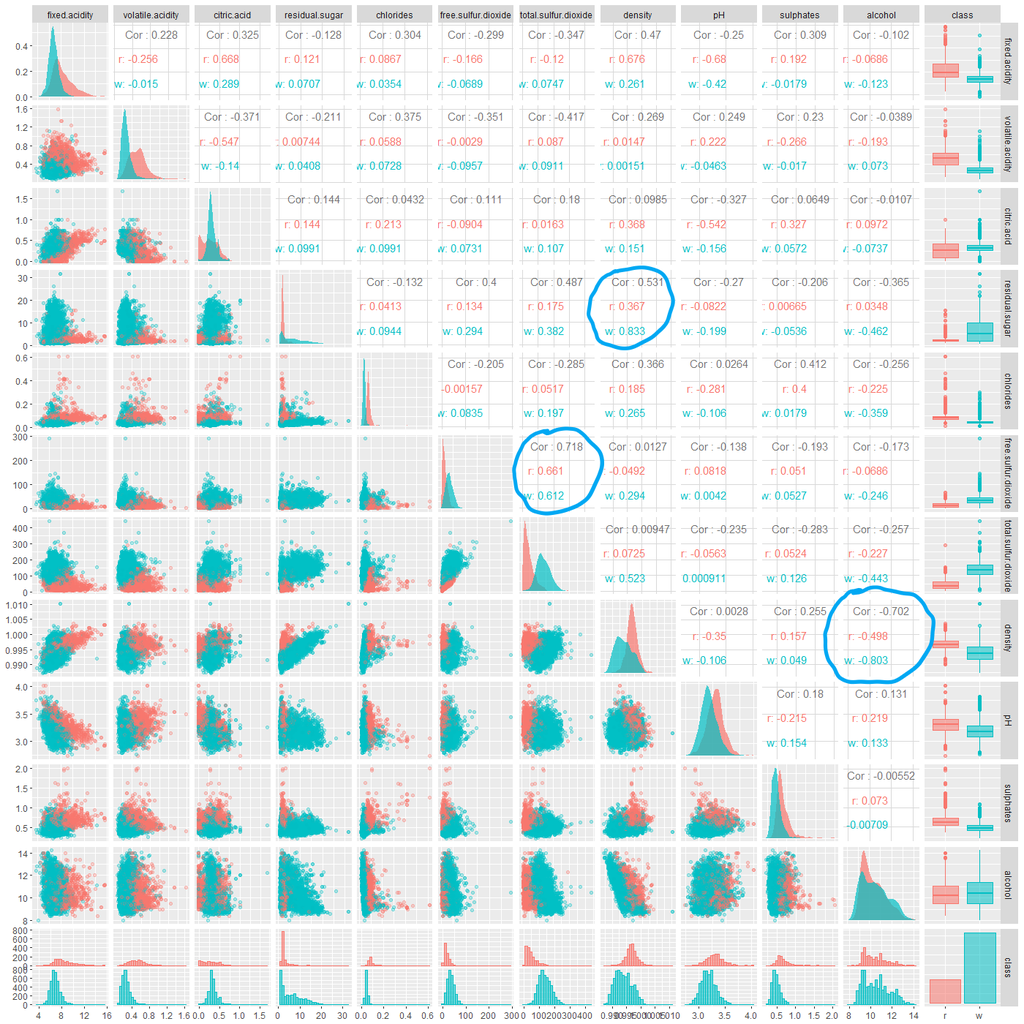

There is only correlation bewteen:

- density and alcohol
- density and residual.sugar
- total.sulfur.dioxid and free.sulfur.dioxid

Further the overview plot shows us that there are some variables which seem to be appropriate to distinguish between red and white wine. When looking at their distribution some favorites are:

- volatile.acidity
- residual sugar
- chlorides
- total.sulfur.dioxide

Let’s see if we will find them later beeing selected in our variable choosing methods.

# Feature Engineering

In order to give our prediction models more “insights” we will try to engineer some features

# Dry, Medium dry, Medium, Sweet (only depending on sugar level)

But at first let’s have a look at our `residual.sugar` variable and its distribution within the classes:

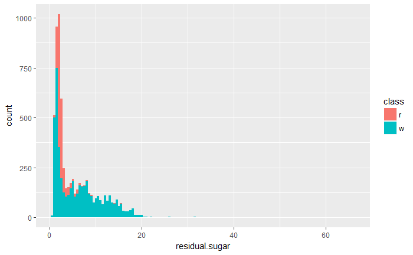

```r
wines %>%
  ggplot() +
  geom_histogram(aes(x = residual.sugar, fill = class), binwidth = 0.5)
```

We can see that red wine does not have many residual sugar values above 10 while white wine has. Let’s introduce our new `product.type` variable:

```r
wines <- wines %>%
  mutate(product.type = factor(ifelse(residual.sugar < 4,
                               "dry",
                               ifelse(residual.sugar < 12,
                                      "medium dry",
                                      ifelse(residual.sugar < 45,
                                             "medium",
                                             "sweet")))))
```

Taking into account our new variable the distribution looks as follows:

```r
table(wines$product.type, wines$class)
```

```
                r    w
  dry        1463 2078
  medium        8  841
  medium dry  128 1978
  sweet         0    1
```

We can also visualize that:

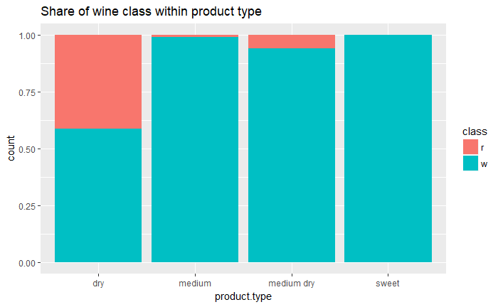

```r
wines %>%
  ggplot() +
  geom_bar(aes(x = product.type, fill = class), position = position_fill()) +
  ggtitle("Share of wine class within product type")
```

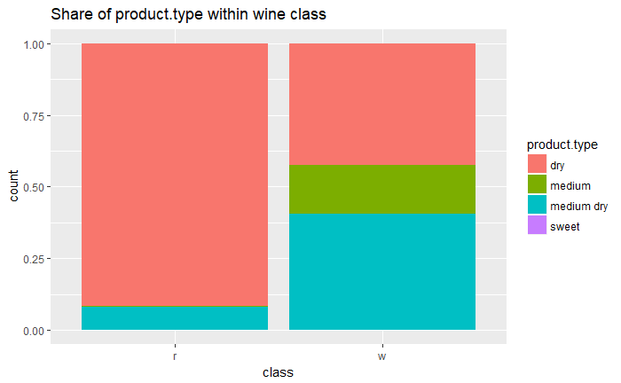

```r
wines %>%
  ggplot() +
  geom_bar(aes(x = class, fill = product.type), position = position_fill()) +
  ggtitle("Share of product.type within wine class")
```

By just looking at the plots, the product.type `sweet` looks like a perfekt predictor for white wine. Unfortunately there is just one (white) wine within this class. That is why we should not use this class for prediction purpose. To overcome this problem we will define the `medium or sweet`class, which includes medium and sweet wines.

```r
table(wines$product.type, wines$class)
```

```
                     r    w
  dry             1463 2078
  medium dry       128 1978
  medium or sweet    8  842
```

Now the distribution looks better. Most of the red wines seem to be dry. There are just few red wines within the other two classes. So our `product.type` variable should be a good predictor.

# Modeling

In order to test our models we need to split our data into a test and a training set. Furthermore we will randomize the row order.

```r
n <- nrow(wines)
set.seed(234)
wines <- wines[sample(n, n),]
set.seed(345)
testRows <- sample(n, floor(0.25*n))
testData <- wines[testRows,]
wines <- wines[-testRows,]
```

## Logistic Regression

### Full Model with cross validation

```r
# train data without class information
trainData <- wines %>%
  dplyr::select(-class)
# class information for trainData
trainClasses <- wines$class
set.seed(1)
lm.full <- caret::train(x = trainData, y = trainClasses,
             method = "glm",
             family = "binomial",
             trControl = trainControl(method = "cv", number = 100))
```

```
glm.fit: fitted probabilities numerically 0 or 1 occurred
```

```r
# average confusionMatrix of lm.full
confusionMatrix.train(lm.full, norm = "average")
```

```
Cross-Validated (100 fold) Confusion Matrix

(entries are average cell counts across resamples)

          Reference
Prediction    r    w
         r 12.0  0.1
         w  0.2 36.5

 Accuracy (average) : 0.9953
```

### Best Subset Selection with max 7 predictors

Next we will try to select the best model by performing a best subset selection. This takes a high amount of computational power since R needs to fit all possible combination of predictors to choose the best one. To speed that process up we will set the maximum number of predictors to `nvmax = 7`.

I did this computation already and saved the model. I will just load the it into the environment.

```r
lm.best <- readRDS("lm.best")
lm.best$BestModels # shows top 5 predictor combinations
```

| fixed.acidity | volatile.acidity | citric.acid | residual.sugar | chlorides | free.sulfur.dioxide | total.sulfur.dioxide | density | pH | sulphates | alcohol | product.type | Criterion |
| --- | --- | --- | --- | --- | --- | --- | --- | --- | --- | --- | --- | --- |
| FALSE | TRUE | FALSE | TRUE | TRUE | TRUE | TRUE | TRUE | FALSE | FALSE | TRUE | FALSE | 309.5179 |
| TRUE | TRUE | FALSE | TRUE | TRUE | FALSE | TRUE | TRUE | FALSE | FALSE | TRUE | FALSE | 316.5663 |
| TRUE | TRUE | FALSE | TRUE | FALSE | TRUE | TRUE | TRUE | FALSE | FALSE | TRUE | FALSE | 319.8978 |
| FALSE | TRUE | FALSE | TRUE | TRUE | FALSE | TRUE | TRUE | FALSE | FALSE | TRUE | FALSE | 320.9256 |
| FALSE | TRUE | TRUE | TRUE | TRUE | FALSE | TRUE | TRUE | FALSE | FALSE | TRUE | FALSE | 321.6351 |

Interestingly `product.type` is not part of the model. But let’s see how the best subset model performes in 10-fold cross validation.

```r
# fit best model using cross validation
trainData <- wines %>%
  dplyr::select(volatile.acidity, chlorides, residual.sugar,
                free.sulfur.dioxide, total.sulfur.dioxide, density, alcohol)
set.seed(1)
lm.best.fit <- caret::train(x = trainData, y = trainClasses,
             method = "glm",
             family = "binomial",
             trControl = trainControl(method = "cv"))
confusionMatrix.train(lm.best.fit, norm = "average")
```

```
Cross-Validated (10 fold) Confusion Matrix

(entries are average cell counts across resamples)

          Reference
Prediction     r     w
         r 119.4   1.0
         w   1.7 365.2

 Accuracy (average) : 0.9945
```

### Stepwise Forward Selection

Now we want to see weather stepwise forward selection would be a good approach to get to an model with similar accuracy as our best subset model. For that purpose we use the `step()` function.

```r
trainData <- data.frame(rep(1, length(trainClasses)))
null <- glm(formula = class ~ 1, family = "binomial", data = wines) #null model
full <- glm(formula = class ~., family = "binomial", data = wines) #full model
step(null, scope = list(lower = null,
                                   upper = full),
     direction = "forward", trace = FALSE)
```

[output not shown]

```
Call:  glm(formula = class ~ total.sulfur.dioxide + density + residual.sugar +
    alcohol + volatile.acidity + chlorides + free.sulfur.dioxide +
    fixed.acidity + pH, family = "binomial", data = wines)

Coefficients:
         (Intercept)  total.sulfur.dioxide               density        residual.sugar
           2.672e+03             6.928e-02            -2.683e+03             1.113e+00
             alcohol      volatile.acidity             chlorides   free.sulfur.dioxide
          -2.944e+00            -6.354e+00            -2.350e+01            -8.675e-02
       fixed.acidity                    pH
           1.160e+00             4.880e+00

Degrees of Freedom: 4872 Total (i.e. Null);  4863 Residual
Null Deviance:      5465
Residual Deviance: 232.6    AIC: 252.6
```

```r
trainData <- wines %>%
  dplyr::select(total.sulfur.dioxide, density , residual.sugar ,
    alcohol, volatile.acidity, chlorides , free.sulfur.dioxide ,
    fixed.acidity, pH)
set.seed(1)
lm.forward <- caret::train(x = trainData, y = trainClasses,
             method = "glm",
             family = "binomial",
             trControl = trainControl(method = "cv"))
```

```
glm.fit: fitted probabilities numerically 0 or 1 occurred
```

```r
confusionMatrix.train(lm.forward, norm = "average")
```

```
Cross-Validated (10 fold) Confusion Matrix

(entries are average cell counts across resamples)

          Reference
Prediction     r     w
         r 119.6   1.0
         w   1.5 365.2

 Accuracy (average) : 0.9949
```

### Stepwise backward selection

Let’s see if the Stepwise backward selection would select a similar model:

```r
trainData <- data.frame(rep(1, length(trainClasses)))
null <- glm(formula = class ~ 1, family = "binomial", data = wines) #null model
full <- glm(formula = class ~., family = "binomial", data = wines) #full model
step(full, scope = list(lower = null,
                                   upper = full),
     direction = "backward", trace = FALSE)
```

[output not shown]

```
Call:  glm(formula = class ~ fixed.acidity + volatile.acidity + residual.sugar +
    chlorides + free.sulfur.dioxide + total.sulfur.dioxide +
    density + pH + alcohol, family = "binomial", data = wines)

Coefficients:
         (Intercept)         fixed.acidity      volatile.acidity        residual.sugar
           2.672e+03             1.160e+00            -6.354e+00             1.113e+00
           chlorides   free.sulfur.dioxide  total.sulfur.dioxide               density
          -2.350e+01            -8.675e-02             6.928e-02            -2.683e+03
                  pH               alcohol
           4.880e+00            -2.944e+00

Degrees of Freedom: 4872 Total (i.e. Null);  4863 Residual
Null Deviance:      5465
Residual Deviance: 232.6    AIC: 252.6
```

Backward selection gives us the same predictors as forward selection.

## Linear Discriminant Analyis

Next we will fit some LDA Models

### Full Model

```r
set.seed(1)
lda.full <- caret::train(class ~., data = wines,
             method = "lda",
             trControl = trainControl(method = "cv"))
# average confusionMatrix of lm.full
confusionMatrix.train(lda.full, norm = "average")
```

```
Cross-Validated (10 fold) Confusion Matrix

(entries are average cell counts across resamples)

          Reference
Prediction     r     w
         r 119.8   1.2
         w   1.3 365.0

 Accuracy (average) : 0.9949
```

The full LDA Model also has a very good performance.

### LDA with best subset from logistic regression

```r
set.seed(1)
lda.best <- caret::train(class ~ volatile.acidity + chlorides + residual.sugar +
                free.sulfur.dioxide + total.sulfur.dioxide + density + alcohol,
                data = wines,
             method = "lda",
             trControl = trainControl(method = "cv"))
# average confusionMatrix of lm.full
confusionMatrix.train(lda.best, norm = "average")
```

```
Cross-Validated (10 fold) Confusion Matrix

(entries are average cell counts across resamples)

          Reference
Prediction     r     w
         r 119.1   1.0
         w   2.0 365.2

 Accuracy (average) : 0.9938
```

The LDA with best subset predictors from logistic regression has a slighty worse accuracy than the others.

## Quadratic Discriminant Analysis

```r
set.seed(1)
qda.full <- caret::train(class ~., data = wines,
             method = "qda",
             trControl = trainControl(method = "cv"))
# average confusionMatrix of lm.full
confusionMatrix.train(qda.full, norm = "average")
```

```
Cross-Validated (10 fold) Confusion Matrix

(entries are average cell counts across resamples)

          Reference
Prediction     r     w
         r 119.4   6.9
         w   1.7 359.3

 Accuracy (average) : 0.9824
```

## Decision tree

```r
trainData <- wines %>%
  dplyr::select(-class)
set.seed(1)
tree <- caret::train(x = trainData, y = trainClasses,
             method = "rpart",
             trControl = trainControl(method = "cv"))
# average confusionMatrix of lm.full
confusionMatrix.train(tree, norm = "average")
```

```
Cross-Validated (10 fold) Confusion Matrix

(entries are average cell counts across resamples)

          Reference
Prediction     r     w
         r 101.4   6.0
         w  19.7 360.2

 Accuracy (average) : 0.9473
```

## Random Forest

```r
trainData <- wines %>%
  dplyr::select(-class)
set.seed(1)
rf <- caret::train(x = trainData, y = trainClasses,
             method = "rf",
             trControl = trainControl(method = "cv"))
# average confusionMatrix of lm.full
confusionMatrix.train(rf, norm = "average")
```

```
Cross-Validated (10 fold) Confusion Matrix

(entries are average cell counts across resamples)

          Reference
Prediction     r     w
         r 119.5   0.3
         w   1.6 365.9

 Accuracy (average) : 0.9961
```

## Compairing Cross Validation Accuracy of all Models

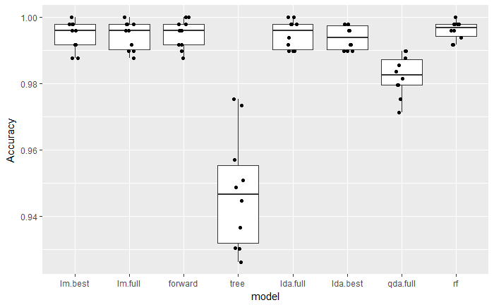